# PS2 Weiner

Anna Weiner

2024-01-28

Problem 1: https://github.com/annaweiner2838/PSet2.git

Problem 2:

```r
  library(tidyverse)

# open my data
  gspace = read_csv('greenspace_data_share.csv') #include quotations

# summarize average urban greenspace by region
  table =
    gspace |>
    group_by(Major_Geo_Region) |> #add pipe
    summarize(
      obs = n(), #added comma
      avg = mean(annual_avg_2020), #added _
      weighted_avg = mean(annual_weight_avg_2020) #added _
    )

# output as table
  kable(table, digits = 1L) #added L and changed gspace to table
```

| Major_Geo_Region | obs | avg | weighted_avg |
| --- | --- | --- | --- |
| Africa | 154 | 0.3 | 0.2 |
| Asia | 569 | 0.3 | 0.3 |
| Europe | 128 | 0.3 | 0.3 |
| Latin America and the Caribbean | 120 | 0.3 | 0.3 |
| Northern America | 58 | 0.3 | 0.3 |
| Oceania | 9 | 0.3 | 0.3 |

Problem 3: The green space data covers 1038 urban areas.

Problem 4: In a couple of sentences and with reference to a well-formatted tabulation, describe the green space classification scores for urban areas in 2021. The majority of cities in 2021 scored in one of the low categories (`Exceptionally Low`, `Very Low`, and `Low`). Only one city scored either `Very High` or `Exceptionally High`.

```r
gsscore <- gspace |>
  count('Indicator 2021' = indicator_2021)
kable(gsscore)
```

| Indicator 2021 | n |
| --- | --- |
| Exceptionally Low | 100 |
| High | 62 |
| Low | 394 |
| Moderate | 215 |
| Very High | 1 |
| Very Low | 265 |
| NA | 1 |

Problem 5a: a. In 2015 69 cities scored `High` or above.

```r
print(sum(gspace$peak_NDVI_2015 >= 0.5))
```

```
## [1] 69
```

Problem 5b: Scored `Exceptionally Low` at any point in the years covered.

```r
except_low <- gspace |>
  summarize(
    `2010` = sum(indicator_2010 == 'Exceptionally Low', na.rm = TRUE),
    `2015` = sum(indicator_2015 == 'Exceptionally Low', na.rm = TRUE),
    `2020` = sum(indicator_2020 == 'Exceptionally Low', na.rm = TRUE),
    `2021` = sum(indicator_2021 == 'Exceptionally Low', na.rm = TRUE)
  )
kable(except_low)
```

| 2010 | 2015 | 2020 | 2021 |
| --- | --- | --- | --- |
| 231 | 90 | 85 | 100 |

Problem 5c: Urban areas in arid climate that became greener (as measured by annual weighted average) from 2010 to 2020.

```r
result = gspace |>
  filter(Climate_region == 'Arid') |>
  mutate(
    greener = ifelse(annual_weight_avg_2020 > annual_weight_avg_2010, 'Greener', 'Not Greener')
  )
count(result, greener)
```

```
## # A tibble: 2 × 2
##   greener         n
##   <chr>       <int>
## 1 Greener       225
## 2 Not Greener     5
```

Problem 6: How many urban areas became less green (measured by annual average) from 2010 to 2021? Were these changes concentrated in a particular geographic or climate region? Explain (with evidence, of course).

```r
result = gspace |>
  group_by(Climate_region) |>
  mutate(
    greener = ifelse(annual_avg_2021 > annual_avg_2010, 'Greener', 'Not Greener'),
  ) |>
  summarize(greener == 'Not Greener')
table(result)
```

```
##               greener == "Not Greener"
## Climate_region FALSE TRUE
##    Arid          218   12
##    Continental   106   36
##    Polar           0    1
##    Temperate     327   45
##    Tropical      256   34
```

Problem 7: Present a histogram showing the change in greenspace (annual average) from 2010 to 2021. Note that you will need to create a new variable equal to this difference.

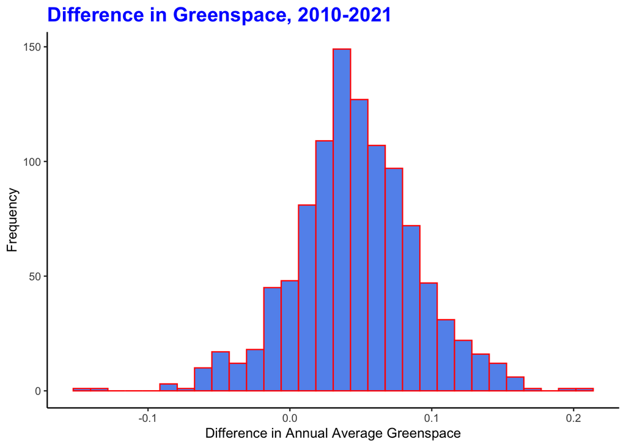

```r
gspace |>
  mutate(gs_difference = annual_avg_2021 - annual_avg_2010) |>
    ggplot(aes(x = gs_difference)) +
  geom_histogram(color = "red", fill = "cornflowerblue") + labs(
    title = "Difference in Greenspace, 2010-2021",
    x = "Difference in Annual Average Greenspace",
    y = "Frequency"
  ) +
  theme_classic() +
  theme(
    plot.title = element_text(color = "blue", size = 16, face = "bold")
  )
```

Problem 8: Present a scatter plot of population weighted greenspace in 2021 over the greenspace in 2010.

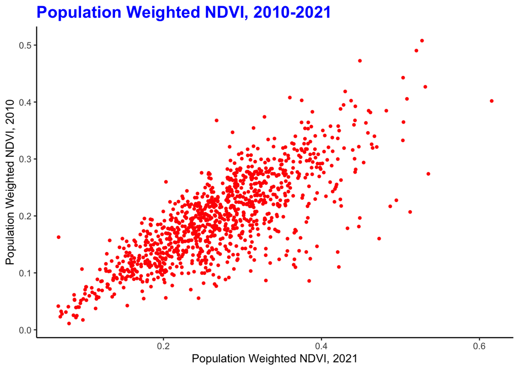

```r
gspace |>
    ggplot(aes(x = annual_weight_avg_2021, y = annual_weight_avg_2010)) +
    geom_point(color = "red", size=1) +
    labs(title = "Population Weighted NDVI, 2010-2021",
    x = "Population Weighted NDVI, 2021",
    y = "Population Weighted NDVI, 2010") +
    theme_classic() +
    theme(plot.title = element_text(color = "blue", size = 16, face = "bold")
  )
```

**BONUS OPPORTUNITY**: Use color-coding to differentiate urban areas that added versus lost greenspace in that time. Then include a 45-degree line to further highlight the change.